# Análisis estimación Salarios femeninos

Lorena Rodriguez Chamorro

1 de septiembre de 2018

## ANÁLISIS ESTIMACIÓN SALARIOS FEMENINOS

Una vez realizada la estimación de los salarios del dataset formado únicamente por las mujeres, a partir de técnicas de Machine Learning entrenando y testeando los modelos únicamente con el dataset de hombres, conseguimos una estimación del salario a partir de variables dependientes relacionadas con el trabajo realizado como nivel de estudios, actividad, tamaño del centro etc.

Si no existieran diferencias salariales por cuestiones de género a igualdad de condiciones laborales, el salario real y el estimado deberían ser muy similares.

A continuación vamos a analizar las posibles diferencias entre lo estimado y lo real.

Comenzamos calculando el salario medio real para los hombres con tipo de jornada a tiempo completo y lo compararemos con el salario estimado que hemos calculado a través de técnicas de aprendizaje automático.

```
##          Real Estimado
## [1,] 28317.92 28160.64
```

Como podemos observar, el salario medio estimado es muy similar al salario medio real en el caso de los hombres, vamos a analizar estas dos métricas en el caso del dataset femenino.

```
##       Real Estimado diferencia DifPorcentual
## 1 25041.86 28346.75   3304.893      13.19747
```

Podemos observar una diferencia considerable entre el salario Real de las mujeres y el salario Estimado (más de 3000 euros), es decir el modelo entrenado a partir del conjunto de datos masculino sobreestima el salario femenino, por lo que podemos concluir que realmente existen diferencias salariales por cuestión de género.

A continuación, vamos a analizar en qué condiciones existe mayor diferencia entre el salario Real y el Estimado.

Comenzamos analizando las zonas geográficas:

```
## # A tibble: 7 x 5
##   NUTS1         Real Estimado diferencia DifPorcentual
##   <chr>        <dbl>    <dbl>      <dbl>         <dbl>
## 1 COM. MADRID 28573.   33079.      4506.         15.8
## 2 ESTE        24492.   28190.      3698.         15.1
## 3 NOROESTE    22275.   25517.      3243.         14.6
## 4 SUR         23599.   26529.      2930.         12.4
## 5 CENTRO      23051.   25605.      2554.         11.1
## 6 NORESTE     27202.   29174.      1972.          7.25
## 7 CANARIAS    21917.   23163.      1245.          5.68
```

La comunidad de Madrid es dónde mayor diferencia existe entre el salario estimado y el real siendo el estimado un 15,8% superior al real, por el contrario Canarias es la zona geográfica con menor diferencia un 5,7% superior.

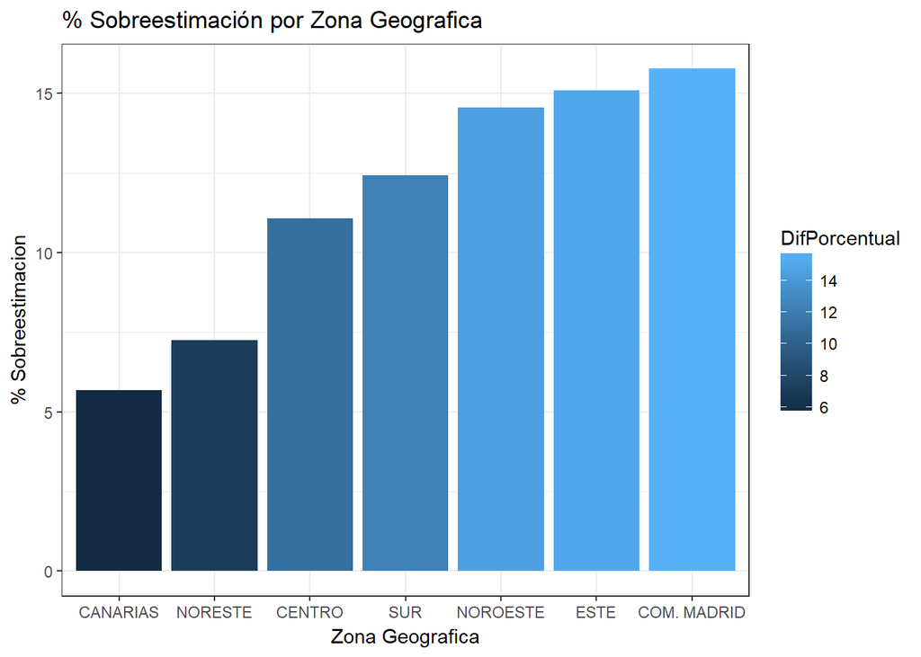

Si analizamos la actividad económica nos encontramos con que otros servicios, actividades asociativas… es la actividad que mayor sobreestimación tiene, casi un 30%, seguida de actividades administrativas y servicios auxiliares. Por el contrario, Transporte y almacenamiento y hostelería son las actividades con menor diferencia entre el salario estimado y el real con menos de un 5%.

```
## # A tibble: 2 x 5
##   DES_CNACE                         Real Estimado diferencia DifPorcentual
##   <chr>                            <dbl>    <dbl>      <dbl>         <dbl>
## 1 Otros servicios: actividades a~ 18094.   23325.      5231.          28.9
## 2 Actividades administrativas y ~ 20037.   24555.      4518.          22.5
```

```
## # A tibble: 2 x 5
##   DES_CNACE                         Real Estimado diferencia DifPorcentual
##   <chr>                            <dbl>    <dbl>      <dbl>         <dbl>
## 1 Transporte y almacenamiento: a~ 24802.   25798.       996.          4.02
## 2 Hostelería: servicios de aloja~ 18181.   18770.       589.          3.24
```

El siguiente gráfico muestra la diferencia porcentual del salario real y el estimado por códigos de actividad:

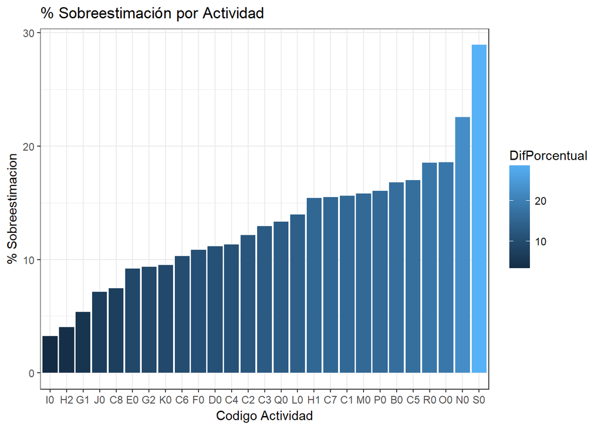

A continuación analizamos las diferencias por ocupación.

```
## # A tibble: 2 x 5
##   DES_TCNO                          Real Estimado diferencia DifPorcentual
##   <chr>                            <dbl>    <dbl>      <dbl>         <dbl>
## 1 OCUPACIONES MILITARES            9681.   19910.     10228.         106.
## 2 TRABAJADORES DE LOS SERVICIOS ~ 18264.   23872.      5608.          30.7
```

```
## # A tibble: 2 x 5
##   DES_TCNO                          Real Estimado diferencia DifPorcentual
##   <chr>                            <dbl>    <dbl>      <dbl>         <dbl>
## 1 TÉCNICOS Y PROFESIONALES CIENT~ 33240.   34046.      806.         2.42
## 2 TRABAJADORES DE LOS SERVICOS D~ 24633.   24650.       17.2        0.0698
```

Ocupaciones militares es la que mayor diferencia presenta entre el salario estimado y el real, siendo el estimado más de 100% superior al real, le sigue los trabajadores de los servicios de salud y el cuidad de las personas con una sobreestimación de más del 30%.

Por el contrario, técnicos y profesionales científicos e intelectuales y trabajadores de los servicios de protección y seguridad son los que presentan un valor estimado más acorde con el real.

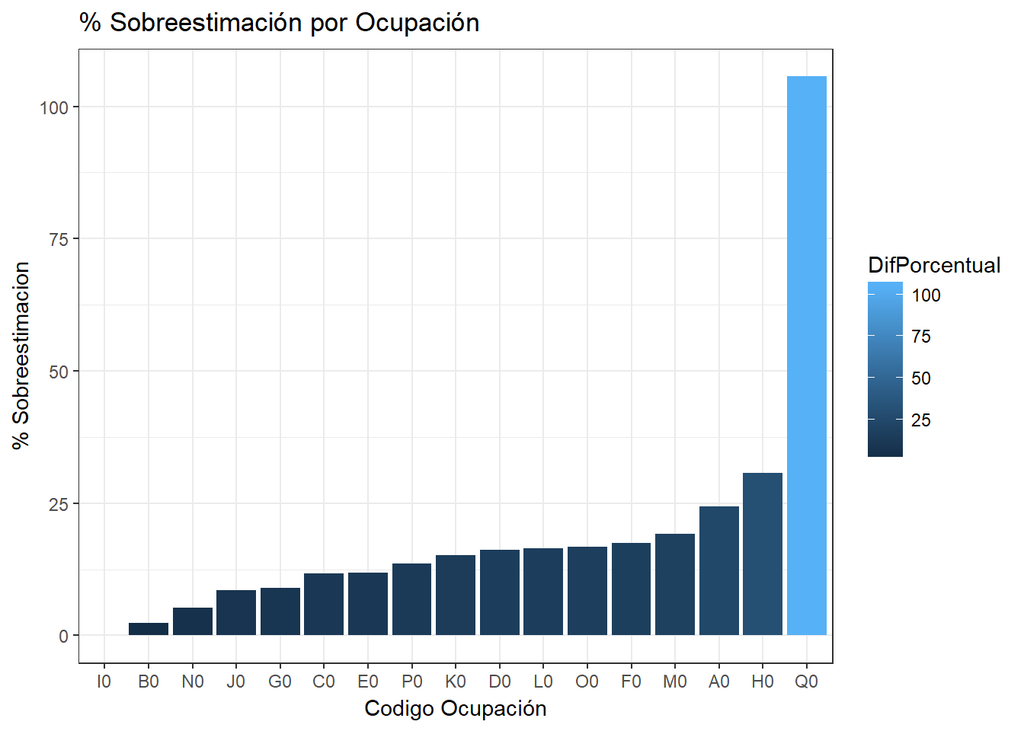

Si analizamos el tipo de contrato, la mayor diferencia entre Estimado y real se presenta en los contratos con duración indefinida.

```
## # A tibble: 2 x 5
##   TIPOCON                Real Estimado diferencia DifPorcentual
##   <chr>                 <dbl>    <dbl>      <dbl>         <dbl>
## 1 DURACION INDEFINIDA  25805.   29427.      3622.         14.0
## 2 DURACION DETERMINADA 21189.   22894.      1705.          8.05
```

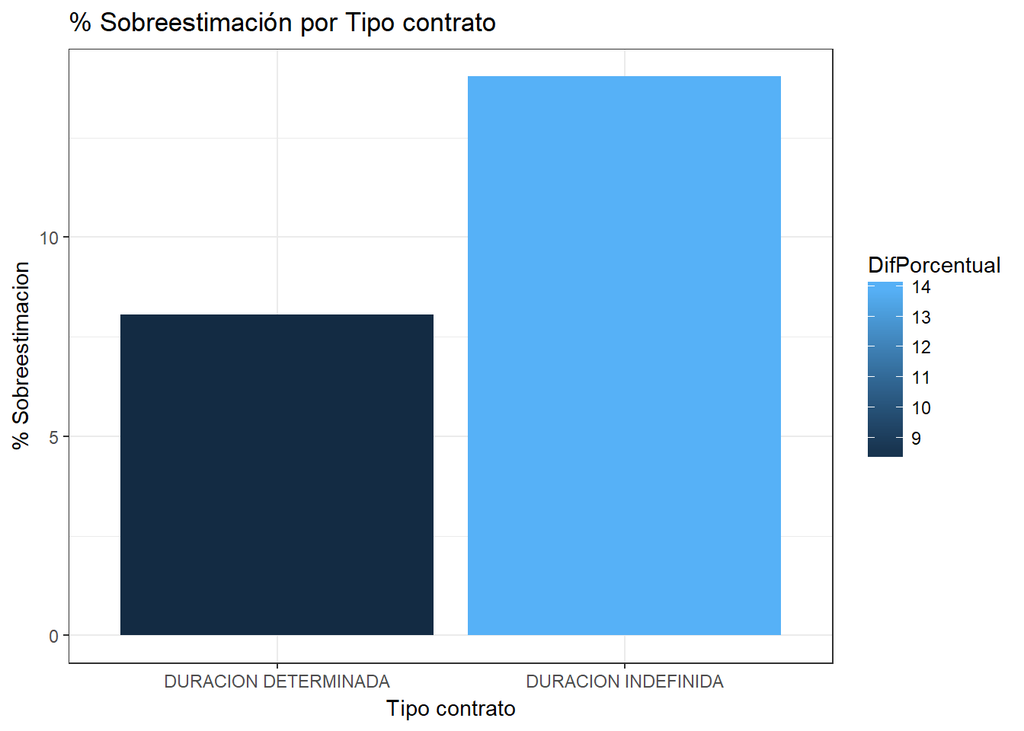

Si analizamos el nivel de estudios, nos encontramos que dónde mayor diferencia salarial existe es en las enseñanzas de formación profesional de grado superior con casi un 18%, seguida de segunda etapa de educacicón secundaria. Los licenciados y similares son los que menor diferencia salarial entre género presentan.

```
## # A tibble: 7 x 5
##   ESTU                              Real Estimado diferencia DifPorcentual
##   <chr>                            <dbl>    <dbl>      <dbl>         <dbl>
## 1 5.Enseñanzas de formación prof~ 23159.   27252.      4093.         17.7
## 2 4.Segunda etapa de educacion s~ 21421.   25162.      3741.         17.5
## 3 2.Educacion primaria            16873.   19465.      2593.         15.4
## 4 6.Diplomados universitarios y ~ 29262.   33100.      3838.         13.1
## 5 3.Primera etapa de educacion s~ 19065.   21546.      2481.         13.0
## 6 1.Menos que primaria            17287.   19400.      2114.         12.2
## 7 7.Licenciados y similares, y d~ 35495.   38710.      3215.          9.06
```

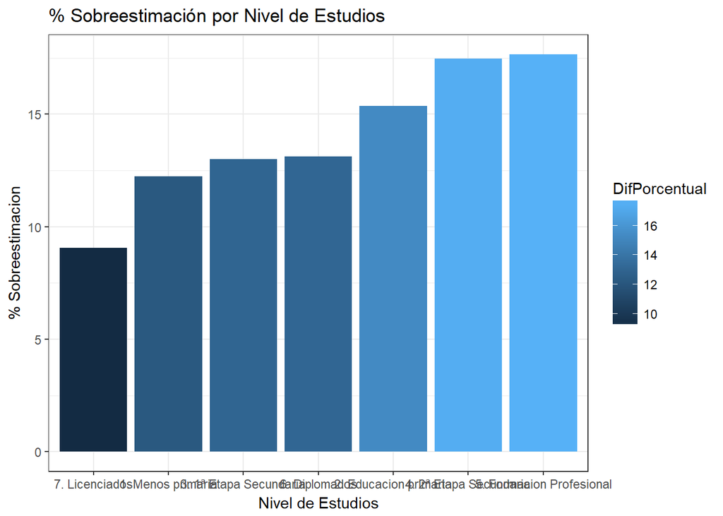

Al analizar la edad, nos encontramos que las diferencias salariales van aumentando a medida que aumenta la edad, llegando a superar el 19% de sobreestimación en las mujeres con más de 59 años.

```
## # A tibble: 6 x 5
##   ANOS2             Real Estimado diferencia DifPorcentual
##   <chr>            <dbl>    <dbl>      <dbl>         <dbl>
## 1 6.MAS DE 59     26809.   31963.      5154.         19.2
## 2 5.DE 50 A 59    27383.   31938.      4555.         16.6
## 3 4.DE 40 A 49    26610.   30577.      3967.         14.9
## 4 3.DE 30 A 39    23908.   26179.      2272.          9.50
## 5 2.DE 20 A 29    18570.   19884.      1314.          7.07
## 6 1.MENOS 19 AÑOS 14310.   14966.       656.          4.58
```

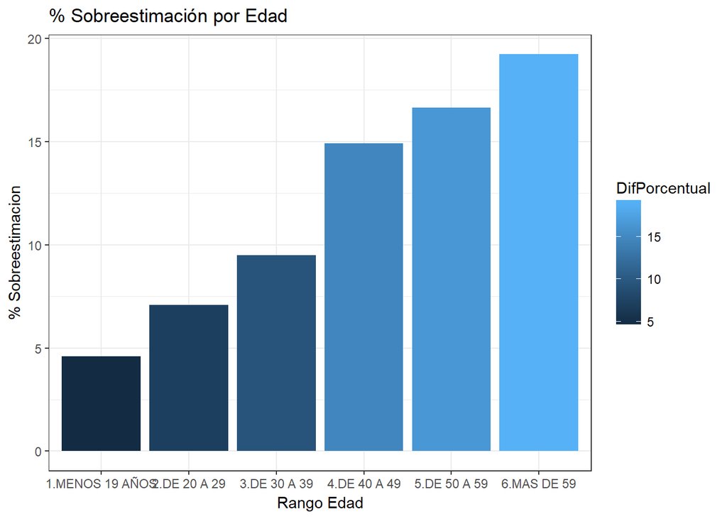

En el siguiente gráfico observamos la diferencia salarial entre Estimado y Real por los años de antiguedad en la empresa, dónde parece observarse que en antiguedad de pocos años es dónde menor diferencia existe.

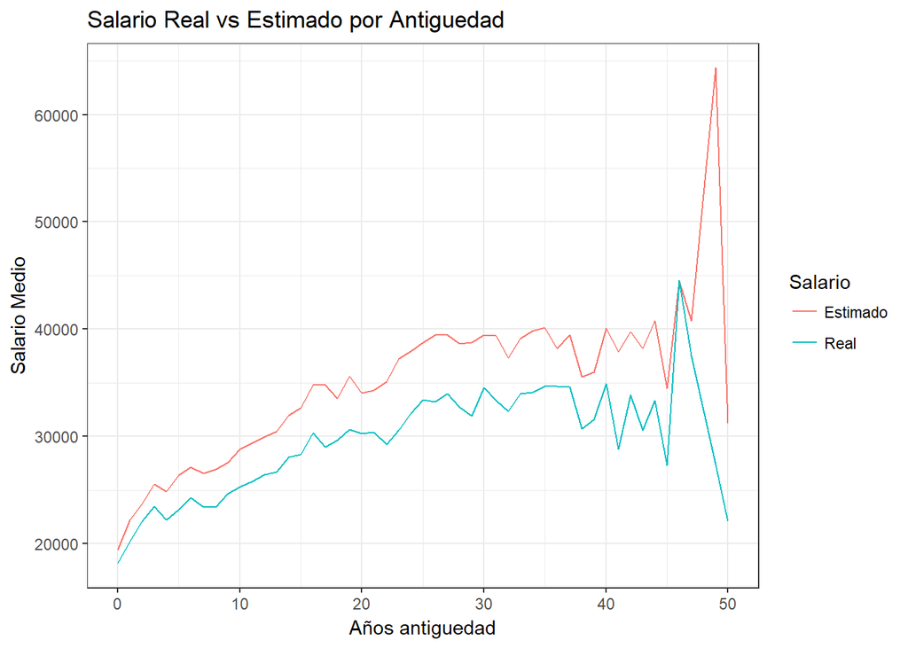

```
## # A tibble: 5 x 5
##   ESTRATO2                        Real Estimado diferencia DifPorcentual
##   <chr>                          <dbl>    <dbl>      <dbl>         <dbl>
## 1 1. INCLUYE TODOS LOS ESTRATOS 21367.   24811.      3445.          16.1
## 2 3.DE 50 A 199 TRABAJADORES    25362.   29079.      3717.          14.7
## 3 4.200 Y MAS TRABAJADORES      28914.   33101.      4187.          14.5
## 4 2.DE 1  A 49 TRABAJADORES     20955.   23178.      2223.          10.6
## 5 5.INCLUYE ESTRATO 2 Y 3       25422.   28062.      2640.          10.4
```

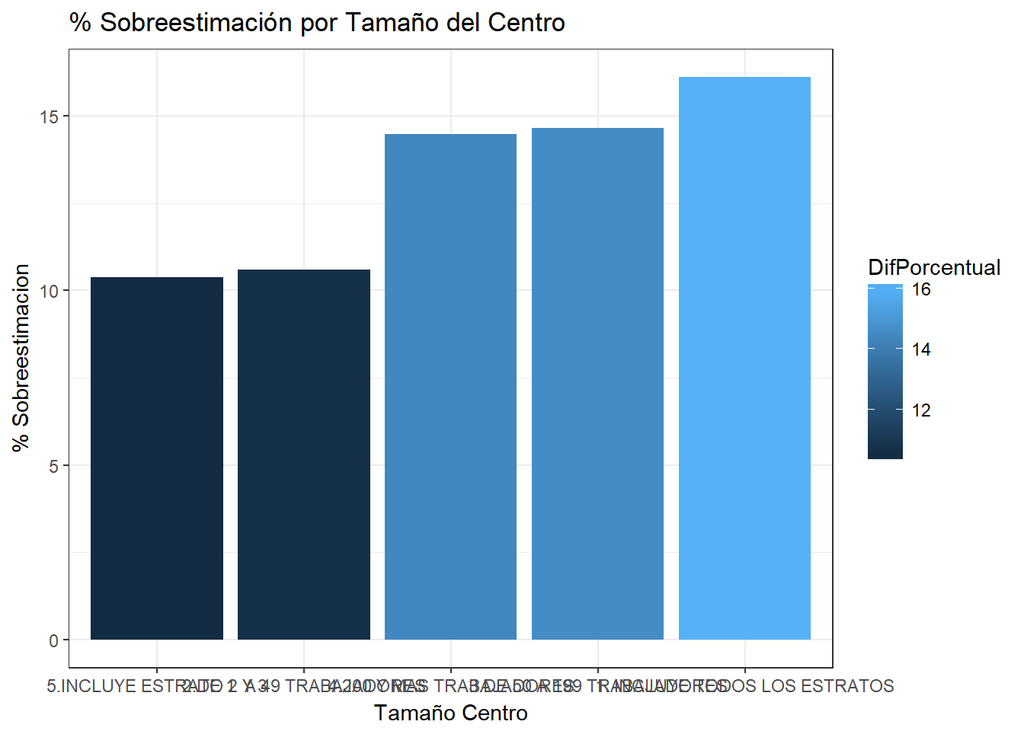

Si estudiamos el salario por el tipo de convenio colectivo, tenemos que de centro de trabajo presenta una sobreestimación de más de un 16% siendo el tipo de convenio con mayor direrencia entre el salario estimado y el real, por el contrario, sectorial de ámbito inferior con un 11,4% de sobreestimación es el tipo de convenio con menor diferencia.

```
## # A tibble: 5 x 5
##   REGULACION                       Real Estimado diferencia DifPorcentual
##   <chr>                           <dbl>    <dbl>      <dbl>         <dbl>
## 1 DE CENTRO DE TRABAJO           26668.   30954.      4286.          16.1
## 2 DE EMPRESA O GRUPO DE EMPRESAS 28523.   32793.      4270.          15.0
## 3 ESTATAL SECTORIAL              24520.   27955.      3435.          14.0
## 4 OTRA FORMA DE REGULACIÓN       28871.   32604.      3733.          12.9
## 5 SECTORIAL DE AMBITO INFERIOR   21932.   24438.      2506.          11.4
```

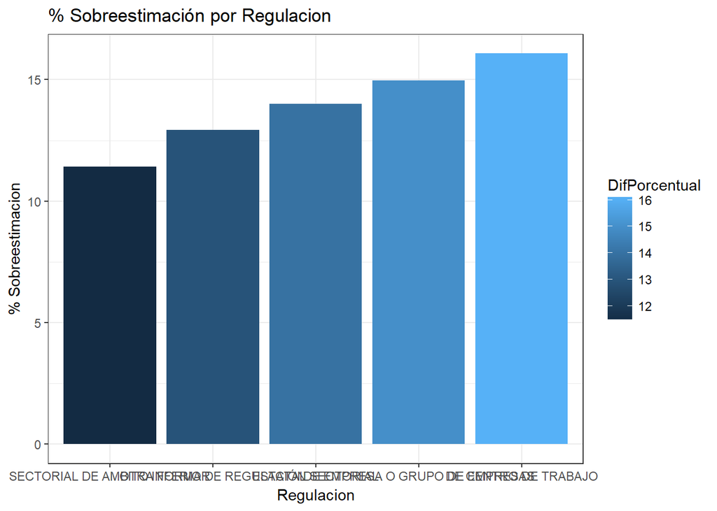

Por último, analizamos el tipo de mercado de destino de la empresa, dónde nos encontramos que si el destino es Union Europea presenta menor sobreestimación que el resto, situándose en un 10,8% mientras que el resto de mercado supera el 13%.

```
## # A tibble: 4 x 5
##   MERCADO            Real Estimado diferencia DifPorcentual
##   <chr>             <dbl>    <dbl>      <dbl>         <dbl>
## 1 MUNDIAL          30948.   35159.      4212.          13.6
## 2 LOCAL O REGIONAL 23577.   26719.      3142.          13.3
## 3 NACIONAL         25821.   29225.      3403.          13.2
## 4 UNION EUROPEA    25417.   28163.      2746.          10.8
```

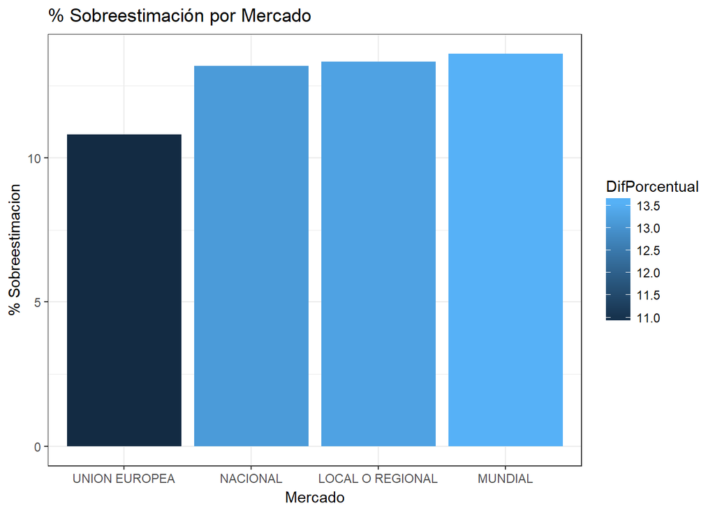

### CONCLUSIONES

[output not shown]